# Simulating MPOX disease SIR dynamics, considering contact mixing

Shadrach Mintah, Benjamin Tommy Bavug, Kama Mary Ofuru, Victoria Nakalanzi

MPOX (Monkeypox) is a viral zoonotic disease caused by the Monkeypox virus, primarily affecting central and West African regions but recently spreading to other parts of the world. It transmits from animals to humans and between humans through close contact with lesions, body fluids, or respiratory droplets. Symptoms include fever, rash, and swollen lymph nodes.

This model simulates the spread of MPOX in two distinct age groups—children and adults—using an SIR (Susceptible, Infected, Recovered) framework. It explores disease dynamics within and across these groups, focusing on how the virus spreads, the rate of recovery, and immunity formation over time.

The model divides the population into three compartments: Susceptible (S), Infectious (I), and Recovered (R) individuals. The model equations describe the flow of individuals between these compartments based on the transmission rate ($\beta$) and the recovery rate ($\gamma$).

## ASSUMPTIONS

The SIR (Susceptible-Infected-Recovered) models for children and adults make several key assumptions about the population, transmission dynamics, and disease progression. Here is a list of the main assumptions:

1. Population Assumptions
- Homogeneous Mixing: The model assumes that individuals within each age group (children or adults) mix homogeneously, meaning every susceptible individual has an equal chance of coming into contact with an infected individual.
- Fixed Population Size: The total population size is constant over time (N = S + I + R), meaning no births, deaths, or migration in or out of the population.
- Closed Population: The population is closed to external influences such as new infections from outside the population or changes due to natural death rates not related to the disease.
- Age Segmentation: The population is segmented into two distinct groups (children and adults) with no crossover between these groups in terms of contact or infection unless explicitly modeled.
2. Disease Transmission Assumptions
- Direct Transmission: The disease is transmitted through direct contact between susceptible and infected individuals. For children, this transmission is modeled with parameter beta_c, and for adults, it’s modeled with beta_a.
- Constant Transmission Rate: The transmission rate (represented by beta) is constant over time and uniform across the population within each age group.
- No Latent Period: The model assumes that once an individual is infected, they are immediately capable of transmitting the disease (i.e., no latent or exposed state in the model).
3. Recovery and Infectiousness Assumptions
- Fixed Infectious Period: Infected individuals recover at a constant rate (gamma), which is the inverse of the infectious period (assumed to be 14 days in this model).
- Complete Recovery: Once recovered, individuals are assumed to gain complete immunity and cannot be reinfected (hence the transition from I to R).
- No Disease-Induced Death: The model assumes no deaths due to the disease (i.e., infected individuals either recover or remain infected but do not die).
4. Initial Conditions Assumptions
- Initial Infected Proportion: A small portion of the population is infected at the start (I0), and the rest are susceptible (S0 = N - I0). No one starts in the recovered (R) category.
- Equal Infectiousness Across Age Groups: While the population is split into children and adults, it is assumed that individuals within each group have the same transmission and recovery rates.
5. No Behavior Changes Over Time
- No Intervention: The model does not account for behavioral changes, medical interventions, vaccination, or other non-pharmaceutical interventions (e.g., quarantine, social distancing) that could alter the course of the disease.
6. Time Scale
- Fixed Time Horizon: The model runs over a fixed period (365 days in this case) with no changes to model parameters or structure during this time.

## The model function

The SIR model equations is given by:

$$\begin{align}
\frac{dS}{dt} & = \color{orange}{\frac{-\beta S I}{N}} \\
\frac{dI}{dt} & = \color{orange}{\frac{\beta S I}{N}} -
\color{blue}{\gamma I} \\
\frac{dR}{dt} & = \color{blue}{\frac{\gamma I}{N}}
\end{align}$$

where:

- $N$ is the population
- $\frac{dS}{dt}$ is the change in number of $Susceptible$ over time,
- $\frac{dI}{dt}$ is the change in number of $Infected$ over time,
- $\frac{dR}{dt}$ is the change in number of $Recovered$ over time,
- $\beta$ is the transmission rate,
- $\gamma$ is the recovered rate.

but

$$\begin{align}
\beta_c = (b1 + b2) ---(1) \\
\beta_a = b3 ------(2)
\end{align}$$

- $b1$ is the transmission by direct contact
- $b2$ is the transmission by airborne
- $b3$ is the transmission by sexual contact
- $\beta_1$ is the transmission rate via direct contact/airbone
- $\beta_2$ is the transmission rate via sexual contact

which translates into:

Transmission from children

$$\begin{align}
\frac{dS_c}{dt} & = \color{orange}{-\beta_c S_c I_c} \\
\frac{dI_c}{dt} & = \color{orange}{\beta_c S_c I_c} -
\color{blue}{\gamma I_c} \\
\frac{dR_c}{dt} & = \color{blue}{\gamma I_c}
\end{align}$$

Transmission from adults

$$\begin{align}
\frac{dS_a}{dt} & = \color{orange}{-\beta_a S_a I_a} \\
\frac{dI_a}{dt} & = \color{orange}{\beta_a S_a I_a} -
\color{blue}{\gamma I_a} \\
\frac{dR_a}{dt} & = \color{blue}{\gamma I_a}
\end{align}$$

where:

- $S_a$ is the number of susceptible individuals(adults),
- $I_a$ is the number of infectious individuals (adults),
- $R_a$ is the number of removal individuals(adults),
- $S_c$ is the number of susceptible individuals(children),
- $I_c$ is the number of infectious individuals (children),
- $R_c$ is the number of removal individuals(children)

$However$

To account for CONTACT MIXING among children and adults after being infected:

for children

$$\begin{align}
\frac{dS_c}{dt} & = \color{orange}{-(\beta_cc S_c I_c + \beta_ac S_c
I_a)} \\
\frac{dI_c}{dt} & = \color{orange}{(\beta_cc S_c I_c + \beta_ac S_c
I_a)} - \color{blue}{\gamma I_c} \\
\frac{dR_c}{dt} & = \color{blue}{\gamma I_c}
\end{align}$$

for adults

$$\begin{align}
\frac{dS_a}{dt} & = \color{orange}{-(\beta_aa S_a I_a + \beta_ca S_c
I_a)} \\
\frac{dI_a}{dt} & = \color{orange}{(\beta_aa S_a I_a + \beta_ca S_c
I_a)} - \color{blue}{\gamma I_a} \\
\frac{dR_a}{dt} & = \color{blue}{\gamma I_a}
\end{align}$$

where:

- $\beta_cc$ is Child to child transmission rate ($\beta_cc$ = $R_0$ * gamma / $N_c$)
- $\beta_aa$ is Adult to adult transmission rate ($\beta_aa$ = $R_0$ * gamma / $N_a$)
- $\beta_ca$ is Child to adult transmission rate ($\beta_ca$ = $R_0$ * gamma / $N_a$)
- $\beta_ac$ is Adult to child transmission rate ($\beta_ac$ = $R_0$ * gamma / $N_c$)

and

- $R_0$ is the Reproduction number of MPOX ($R_0$ = 1.8 for our discussion)
- $N_c$ is population of children below 18 years (<18yrs) in the country (Nigeria)
- $N_a$ is population of children above 18 years (>18yrs) in the country (Nigeria)

## Model for children below 18yrs

```
##   time      S_c      I_c      R_c
## 1    1 94999980 20.00000 0.000000
## 2    2 94999977 21.17614 1.470176
## 3    3 94999975 22.42145 3.026809
## 4    4 94999972 23.73998 4.674983
## 5    5 94999968 25.13606 6.420081
## 6    6 94999965 26.61424 8.267804
```

```
##     time      S_c      I_c      R_c
## 360  360 26236453 852960.2 67910587
## 361  361 26206720 822848.5 67970431
## 362  362 26178070 793768.4 68028161
## 363  363 26150463 765686.9 68083850
## 364  364 26123860 738571.8 68137568
## 365  365 26098225 712391.7 68189383
```

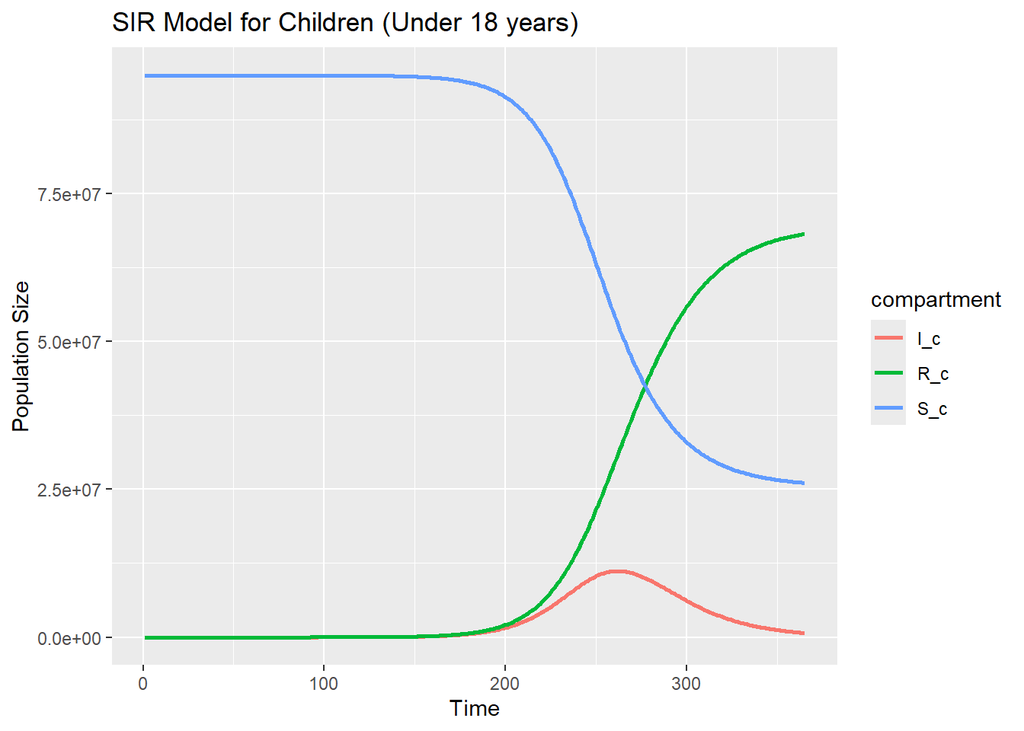

## Model for adults above 18yrs

```
##   time      S_a      I_a      R_a
## 1    1 1.25e+08 20.00000 0.000000
## 2    2 1.25e+08 21.17614 1.470176
## 3    3 1.25e+08 22.42145 3.026809
## 4    4 1.25e+08 23.73998 4.674983
## 5    5 1.25e+08 25.13606 6.420081
## 6    6 1.25e+08 26.61424 8.267804
```

```
##     time      S_a     I_a      R_a
## 360  360 34731142 1332967 88935890
## 361  361 34684396 1286182 89029422
## 362  362 34639351 1240981 89119668
## 363  363 34595946 1197313 89206741
## 364  364 34554120 1155131 89290748
## 365  365 34513817 1114389 89371794
```

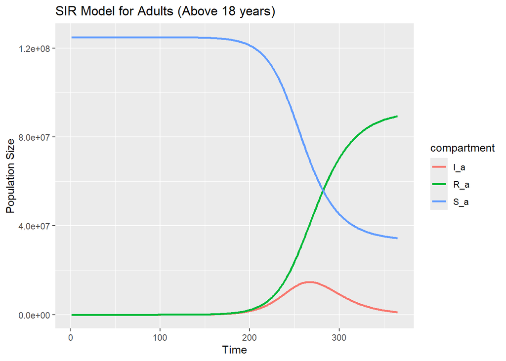

```
##   time      S_c      I_c       R_c      S_a      I_a       R_a
## 1    1 94999990 10.00000 0.0000000 1.25e+08 10.00000 0.0000000
## 2    2 94999987 12.04078 0.7849166 1.25e+08 12.04078 0.7849166
## 3    3 94999984 14.49804 1.7300168 1.25e+08 14.49804 1.7300168
## 4    4 94999980 17.45678 2.8679932 1.25e+08 17.45678 2.8679933
## 5    5 94999975 21.01933 4.2382030 1.25e+08 21.01933 4.2382031
## 6    6 94999969 25.30891 5.8880444 1.25e+08 25.30891 5.8880445
```

```
##     time     S_c      I_c      R_c     S_a      I_a       R_a
## 360  360 1696822 2.328354 93303176 5866291 5.640972 119133703
## 361  361 1696822 2.184955 93303176 5866291 5.297057 119133704
## 362  362 1696822 2.050394 93303176 5866291 4.974102 119133704
## 363  363 1696822 1.924128 93303176 5866291 4.670829 119133704
## 364  364 1696822 1.805644 93303176 5866291 4.386040 119133705
## 365  365 1696822 1.694462 93303176 5866291 4.118608 119133705
```

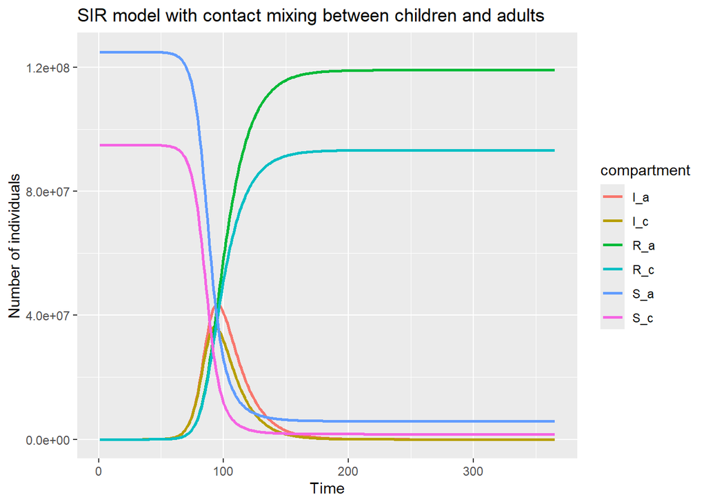